# Semana 07 - code sessions

Panel data y modelo de efectos fijos

Carlos Daboín

June, 2022

# Estimando el modelo económico del crimen con panel data

Hoy replicaremos los resultados de “Estimating the Economic Model of Crime with Panel Data”, de C. Cornwell y W. Trumbull (1994).

**La pregunta:** ¿Qué elementos de la implementación de la justicia son más efectivos en la reducción del crimen?

- El modelo económico del crimen (Becker, 1968) postula que la participación de los ciudadanos en actividades ilegales depende de los retornos relativos estas y en la capacidad del sistema criminal de justicia de afectar las probabilidades de captura y castigo. ¿Cómo podríamos testear este modelo?
- Hasta mediados de los 90s múltiples equipos de economistas habían logrado estimar elasticidades de distintos componentes de la justicia criminal sobre las tasas de criminalidad, pero siempre con datos en sección cruzada a nivel de condado o ciudad (ver Elrich 1973, Sjoquist 1973, Trumbull 1989, y otros), pero nunca a nivel individual o a través del tiempo (que sería lo **ideal**.)
- Hoy discutiremos los aportes de Cromwell y Trumbull (1994) quiénes, analizando datos en panel a nivel de Condado, encuentran que las elasticidades son más débiles que lo que proponían estudios anteriores. [link](https://www.amherst.edu/media/view/121570/original/CornwellTrumbullCrime%2BElasticities.pdf)
- Atribuyen la diferencia a que los resultados previos eran vulnerables a heterogeneidad no observada a nivel de condado (e.g. atributos omitidos que influyen simultáneamente sobre la criminalidad y el *“law enforcement”*)
- ¿Que variable con estas características pudieran estar omitiendo los estudios anteriores? imaginemos que las tasa de reporte del crimen varía a nivel de condado y que es no-observable (lo cúal es bastante plausible): Aquellos condados con mayores tasas de reporte tendrán (en promedio) una mayor tasa de criminalidad y menores tasas de arresto. Una situación así sesgaría la estimación de los efectos de interés, haciéndolos parecer de mayor magnitud.

# 1. Una vista rápida

## Los resultados anteriores

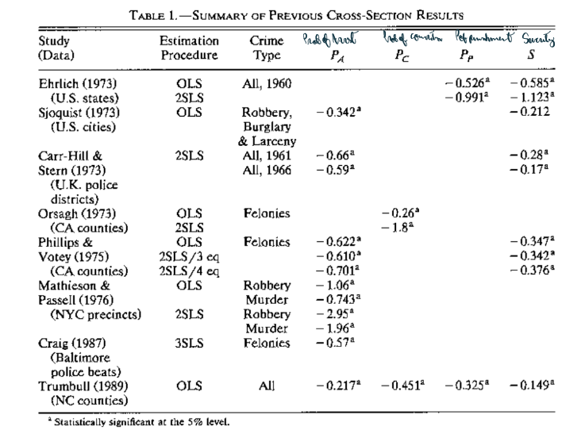

*Source: Cornwell y Trumbull (1994)*